# Time Series Forecasting

## **Time Series Forecasting** **by Mehdi Rezvandehy**

# Summary

Predicting the future is something we want to apply all the time, whether we are finishing a friend’s sentence or anticipating the smell of coffee at breakfast. They can analyze time series data such as stock prices, and tell us when to sell or buy. In autonomous driving systems, they can anticipate car trajectories and help avoid accidents. In this notebook, time series prediction is applied with supervised learning and deep learning for [sunspots](http://www.sidc.be/silso/INFO/sndtotcsv.php) example and [Total Energy Consumption in Alberta](https://www.aeso.ca/market/market-and-system-reporting/). Required Python functions to run this notebook is in Appendix.

```python
import os
import pandas as pd
import numpy as np
import matplotlib as mpl
import matplotlib.pyplot as plt
from pandas import concat
from sklearn.preprocessing import StandardScaler
from sklearn.preprocessing import MinMaxScaler
from sklearn.model_selection import TimeSeriesSplit
from sklearn.model_selection import cross_val_score
from sklearn.ensemble import RandomForestRegressor
from sklearn.model_selection import cross_val_predict
from sklearn.metrics import mean_squared_error
from sklearn.linear_model import LinearRegression
from sklearn.neural_network import MLPRegressor
from sklearn.neighbors import KNeighborsRegressor
from sklearn.tree import DecisionTreeRegressor
import math
import itertools
import xgboost
import tensorflow as tf
from tensorflow import keras
from sklearn.impute import KNNImputer
import warnings
warnings.filterwarnings('ignore')
```

# How to Convert a Time Series to a Supervised Learning Problem in Python

Before machine learning can be used, time series forecasting problems must be re-framed as supervised learning problems. From a sequence to pairs of input and output sequences.

A time series is a sequence of numbers that are ordered by a time index. This can be thought of as a list or column of ordered values.

A supervised learning problem is comprised of input patterns (X) and output patterns (y), such that an algorithm can learn how to predict the output patterns from the input patterns.

[figure not shown]

# Sun Spots Example

In this section, another time series data is presented to predict sunspots. The data is hemispheric sunspot numbers, can downloaded from [sunspots time series](http://www.sidc.be/silso/INFO/sndtotcsv.php). The data set is from 1/1/1818 to now.

```python
Names = ['year', 'month', 'day', 'dec_year', 'sn_value' ,
         'sn_error', 'obs_num']
df_sunspot = pd.read_csv('SN_d_tot_V2.0.csv',sep=';',header=None,names=Names,
                 na_values=['-1'], index_col=False)
df_sunspot['sn_value'].replace(-1, np.nan,inplace=True)
df_sunspot.insert(loc=0, column='No.', value=df_sunspot.index.to_list())

print("Look at first 20 rows:")
print(df_sunspot.iloc[0:20])

print("Look at last 20 rows:")
print(df_sunspot.iloc[-20:])
```

```
Look at first 20 rows:
    No.  year  month  day  dec_year  sn_value  sn_error  obs_num
0     0  1818      1    1  1818.001       NaN       NaN        0
1     1  1818      1    2  1818.004       NaN       NaN        0
2     2  1818      1    3  1818.007       NaN       NaN        0
3     3  1818      1    4  1818.010       NaN       NaN        0
4     4  1818      1    5  1818.012       NaN       NaN        0
5     5  1818      1    6  1818.015       NaN       NaN        0
6     6  1818      1    7  1818.018       NaN       NaN        0
7     7  1818      1    8  1818.021      65.0      10.2        1
8     8  1818      1    9  1818.023       NaN       NaN        0
9     9  1818      1   10  1818.026       NaN       NaN        0
10   10  1818      1   11  1818.029       NaN       NaN        0
11   11  1818      1   12  1818.032       NaN       NaN        0
12   12  1818      1   13  1818.034      37.0       7.7        1
```

[output cut: 29 more lines]

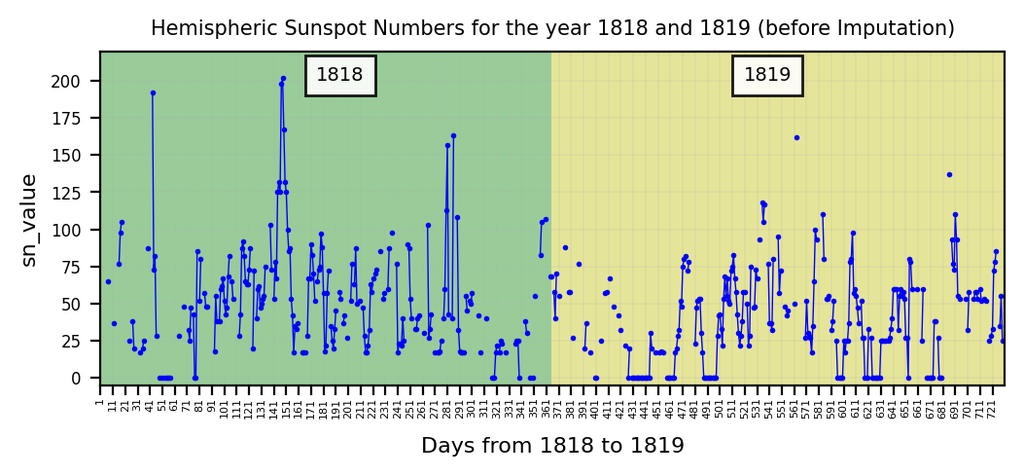

```python
font = {'size'   :6 }
plt.rc('font', **font)
fig=plt.figure(figsize=(6, 5), dpi= 200, facecolor='w', edgecolor='k')
ax1=plt.subplot(2,1,1)
no_day=730
date=df_sunspot[['sn_value']].iloc[0:no_day].values.tolist()
days=df_sunspot['day'].iloc[0:no_day].astype(str).values.tolist()
plt.plot(date,'bo-', markersize=1, linewidth=0.5)
ax1.grid(axis='both',linewidth='0.1')
plt.xticks(np.arange(1,len(days)+1,10))
ax1.set_xticklabels(np.arange(1,len(days)+1,10), rotation=90,fontsize=4,y=0.02)
plt.title('Hemispheric Sunspot Numbers for the year 1818 and 1819 (before Imputation)',fontsize=7.5)
plt.xlabel('Days from 1818 to 1819',fontsize=8,labelpad=7)
plt.ylabel('sn_value',fontsize=8)
plt.xlim((1,no_day+1))

jet= plt.get_cmap('jet')
colors = plt.cm.jet(np.linspace(0,1,2))
plt.axvspan(1,365, facecolor='g', alpha=0.4)
plt.text(175, 200,'1818',fontsize=7,bbox=dict(facecolor='w', alpha=0.9))
plt.axvspan(365,730, facecolor='y', alpha=0.4)
plt.text(520, 200,'1819',fontsize=7,bbox=dict(facecolor='w', alpha=0.9))

plt.ylim((-5,220))
plt.show()
```

## Imputation with KNN

```python
imputer = KNNImputer(n_neighbors=5, weights='uniform')
val=df_sunspot[['No.','sn_value']].values
df_sunspot['sn_value']=imputer.fit_transform(val)[:,1]
```

```python
df_sunspot['sn_value'][(df_sunspot['sn_value']!=-1) & (df_sunspot['year']==1818)].mean()
```

```
50.67232876712326
```

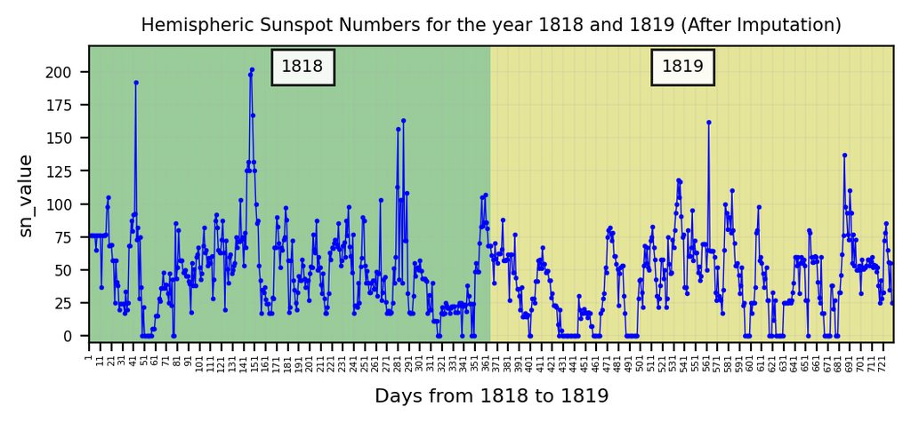

```python
font = {'size'   :6 }
plt.rc('font', **font)
fig=plt.figure(figsize=(6, 5), dpi= 200, facecolor='w', edgecolor='k')
ax1=plt.subplot(2,1,1)
no_day=730
date=df_sunspot[['sn_value']].iloc[0:no_day].values.tolist()
days=df_sunspot['day'].iloc[0:no_day].astype(str).values.tolist()
plt.plot(date,'bo-', markersize=1, linewidth=0.5)
ax1.grid(axis='both',linewidth='0.1')
plt.xticks(np.arange(1,len(days)+1,10))
ax1.set_xticklabels(np.arange(1,len(days)+1,10), rotation=90,fontsize=4,y=0.02)
plt.title('Hemispheric Sunspot Numbers for the year 1818 and 1819 (After Imputation)',fontsize=7.5)
plt.xlabel('Days from 1818 to 1819',fontsize=8,labelpad=7)
plt.ylabel('sn_value',fontsize=8)
plt.xlim((1,no_day+1))

jet= plt.get_cmap('jet')
colors = plt.cm.jet(np.linspace(0,1,2))
plt.axvspan(1,365, facecolor='g', alpha=0.4)
plt.text(175, 200,'1818',fontsize=7,bbox=dict(facecolor='w', alpha=0.9))
plt.axvspan(365,730, facecolor='y', alpha=0.4)
plt.text(520, 200,'1819',fontsize=7,bbox=dict(facecolor='w', alpha=0.9))

plt.ylim((-5,220))
plt.show()
```

```python
print("Look at first 20 rows:")
print(df_sunspot.iloc[:20])

print("Look at last 20 rows:")
print(df_sunspot.iloc[-20:])
```

```
Look at first 20 rows:
    No.  year  month  day  dec_year  sn_value  sn_error  obs_num
0     0  1818      1    1  1818.001      76.4       NaN        0
1     1  1818      1    2  1818.004      76.4       NaN        0
2     2  1818      1    3  1818.007      76.4       NaN        0
3     3  1818      1    4  1818.010      76.4       NaN        0
4     4  1818      1    5  1818.012      76.4       NaN        0
5     5  1818      1    6  1818.015      76.4       NaN        0
6     6  1818      1    7  1818.018      76.4       NaN        0
7     7  1818      1    8  1818.021      65.0      10.2        1
8     8  1818      1    9  1818.023      76.4       NaN        0
9     9  1818      1   10  1818.026      76.4       NaN        0
10   10  1818      1   11  1818.029      76.4       NaN        0
11   11  1818      1   12  1818.032      76.4       NaN        0
12   12  1818      1   13  1818.034      37.0       7.7        1
```

[output cut: 29 more lines]

## Mean Value for each Month

```python
# Monthly average
def date(x):
    if ((x['month'])<10):
        date_=str(int(x['year']))+'-0'+str(int(x['month']))
    else:
        date_=str(int(x['year']))+'-'+str(int(x['month']))
    return date_

df_sunspot['date']=df_sunspot.apply(lambda x: date(x),axis=1 )
df_sunspot_gb=df_sunspot.groupby(['date']).mean()[['sn_value']]
df_sunspot_gb.insert (0, "date", df_sunspot_gb.index)

df_sunspot_gb.reset_index(drop=True, inplace=True)
```

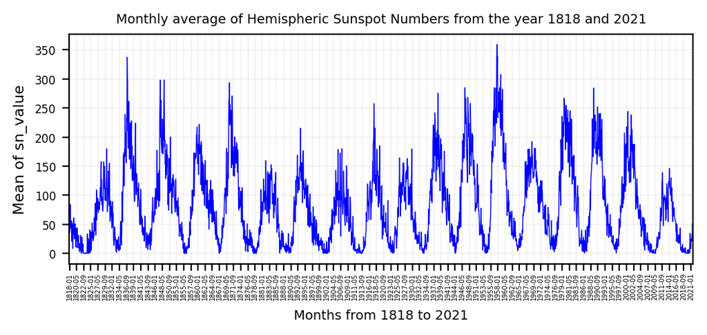

```python
font = {'size'   :6 }
plt.rc('font', **font)
fig=plt.figure(figsize=(6, 5), dpi= 200, facecolor='w', edgecolor='k')
ax1=plt.subplot(2,1,1)

date=df_sunspot_gb['date'].astype(str).values.tolist()
sn_value=df_sunspot_gb['sn_value'].values.tolist()
df_sunspot_gb.insert(loc=0, column='No.', value=np.arange(1,len(sn_value)+1))
plt.plot(date,sn_value,color='b',linewidth=0.5)
ax1.grid(axis='both',linewidth='0.1')
plt.xticks(np.arange(1,len(date)+1),date)
ax1.set_xticklabels(date, rotation=90,fontsize=3.5,y=0.02)
plt.title('Monthly average of Hemispheric Sunspot Numbers from the year 1818 and 2021',fontsize=7)

plt.xlabel('Months from 1818 to 2021',fontsize=7,labelpad=5)
plt.ylabel('Mean of sn_value',fontsize=8)
plt.locator_params(axis='x', nbins=90)
plt.xlim(('1818-01','2021-11'))
plt.show()
```

## Training and Test sets

```python
# Training set for years less than 2021
X_train = df_sunspot_gb[df_sunspot_gb.date<'2021']
X_train.reset_index(drop=True, inplace=True)

# Test set for the year 2021
X_test = df_sunspot_gb[(df_sunspot_gb.date>'2021') & (df_sunspot_gb.date<'2022')]
X_test.reset_index(drop=True, inplace=True)
```

## Prediction with Supervised Learning

```python
# Train LinearRegression
n_input=12 # 12 Months input
n_output=12 # 12 Months output
nsim=1
model=LinearRegression()
pred_no_all,full_test_nsim_all,full_test_nsim_m,MAE_all=time_series_forecst(n_input,n_output
                    ,nsim, model,X_train,clm='sn_value',no='No.',test1=X_test)
```

### Cross-Validation on Time-Series data

**A better alternative for cross validation on time series data (than K-fold CV) is Forward Chaining strategy.**

In forward chaining, say with 3 folds, the train and validation sets look like:

- fold 1: training [1], validation [2]
- fold 2: training [1 2], validation [3]
- fold 3: training [1 2 3], validation [4]

**sklearn has a provision for implementing such train test split using `TimeSeriesSplit`.**

### Predictive Algorithms

```
Linear Regression: 0.662852 (0.078745)
Neural Network: 0.638158 (0.129642)
Decision Tree: 0.310422 (0.167034)
Random Forest: 0.668524 (0.076716)
```

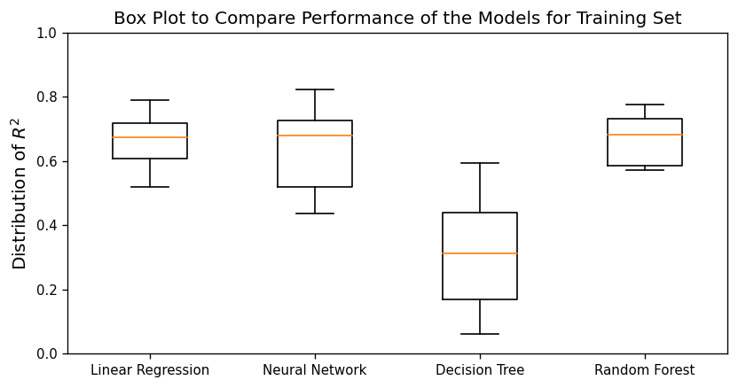

```python
font = {'size'   : 9}
plt.rc('font', **font)
fig, ax1 = plt.subplots(figsize=(8, 4), dpi= 120, facecolor='w', edgecolor='k')

# Spot Check Algorithms
np.random.seed(42)
models = []
models.append(('Linear Regression', LinearRegression()))
models.append(('Neural Network', MLPRegressor(solver = 'lbfgs')))
models.append(('Decision Tree', DecisionTreeRegressor()))
models.append(('Random Forest', RandomForestRegressor(n_estimators = 100)))
# Evaluate each model in turn
results = []
names = []
for name, model in models:
    # TimeSeries Cross validation
    tscv = TimeSeriesSplit(n_splits=10)

    # Train models
    pred_no_all,full_test_nsim_all,full_test_nsim_m,MAE_all,X_train_ts, y_train_ts=time_series_forecst(12,12
                        ,1, model,X_train,clm='sn_value',no='No.', data_out=True,test1=X_test)

    cv_results = cross_val_score(model, X_train_ts, y_train_ts, cv=tscv, scoring='r2')
    results.append(cv_results)
    names.append(name)
    print('%s: %f (%f)' % (name, cv_results.mean(), cv_results.std()))

# Compare Algorithms
plt.ylim((0,1))
plt.boxplot(results,meanline=True, labels=names)
plt.ylabel('Distribution of '+r"$R^{2}$",fontsize=12)
plt.title('Box Plot to Compare Performance of the Models for Training Set',fontsize=12)
plt.show()
```

```python
# Make empty sn_value for year 2022
test_2022=[f'2022-{"%02d" % (i+1,)}' for i in range(12)]
test_2022=pd.DataFrame(test_2022,columns=['date'])
test_2022['sn_value']=len(test_2022)*[np.nan]
#
# Make empty sn_value for year 2023
test_2023=[f'2023-{"%02d" % (i+1,)}' for i in range(12)]
test_2023=pd.DataFrame(test_2023,columns=['date'])
test_2023['sn_value']=len(test_2023)*[np.nan]
#
# Make empty sn_value for year 2024
test_2024=[f'2024-{"%02d" % (i+1,)}' for i in range(12)]
test_2024=pd.DataFrame(test_2024,columns=['date'])
test_2024['sn_value']=len(test_2024)*[np.nan]
#
# Make empty sn_value for year 2025
test_2025=[f'2025-{"%02d" % (i+1,)}' for i in range(12)]
test_2025=pd.DataFrame(test_2025,columns=['date'])
test_2025['sn_value']=len(test_2025)*[np.nan]
```

```python
n_input=12  #12 Month input
n_output=12 #12 Month output

# Number of simulation
nsim=20
model=RandomForestRegressor(n_estimators = 100)
pred_no_all,full_test_nsim_all_rf,full_test_nsim_m_rf,MAE_all_rf,X_train_ts_rf, y_train_ts_rf=time_series_forecst(n_input,n_output
                    ,nsim, model,X_train,clm='sn_value',no='No.', data_out=True,test1=X_test,
                    test2=test_2022,test3=test_2023,test4=test_2024,test5=test_2025)
#
model=LinearRegression()
pred_no_all,full_test_nsim_all_lr,full_test_nsim_m_lr,MAE_all_lr,X_train_ts_lr, y_train_ts_lr=time_series_forecst(n_input,n_output
                    ,nsim, model,X_train,clm='sn_value',no='No.', data_out=True,test1=X_test,
                    test2=test_2022,test3=test_2023,test4=test_2024,test5=test_2025)
#
model=MLPRegressor(solver = 'lbfgs')
pred_no_all,full_test_nsim_all_ml,full_test_nsim_m_ml,MAE_all_ml,X_train_ts_ml, y_train_ts_ml=time_series_forecst(n_input,n_output
                    ,nsim, model,X_train,clm='sn_value',no='No.', data_out=True,test1=X_test,
                    test2=test_2022,test3=test_2023,test4=test_2024,test5=test_2025)
#
model=DecisionTreeRegressor()
pred_no_all,full_test_nsim_all_dt,full_test_nsim_m_dt,MAE_all_dt,X_train_ts_dt, y_train_ts_dt=time_series_forecst(n_input,n_output
                    ,nsim, model,X_train,clm='sn_value',no='No.', data_out=True,test1=X_test,
                    test2=test_2022,test3=test_2023,test4=test_2024,test5=test_2025)
```

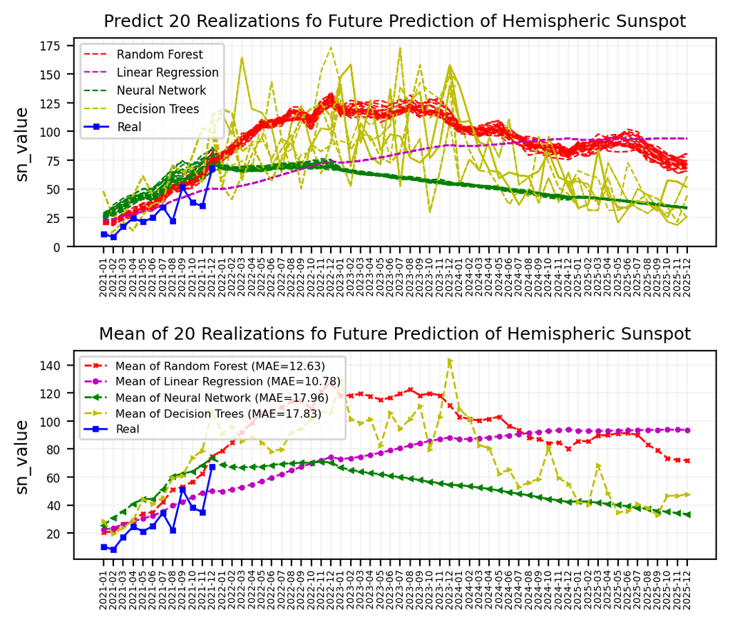

```python
date=X_test['date'].astype(str).values.tolist()+test_2022['date'
            ].astype(str).values.tolist()+test_2023['date'].astype(str).values.tolist()+test_2024['date'
            ].astype(str).values.tolist()+test_2025['date'].astype(str).values.tolist()

date_real=X_test['sn_value'].to_list()+test_2022['sn_value'].to_list()+test_2023['sn_value'
            ].to_list()+test_2024['sn_value'].to_list()+test_2025['sn_value'].to_list()

font = {'size'   :6 }
plt.rc('font', **font)
fig=plt.figure(figsize=(6, 5), dpi= 200, facecolor='w', edgecolor='k')
ax1=plt.subplot(2,1,1)

# Number of prediction
n_pred= 5
# Make realizations
for i in range(nsim):
    real=[]
    for j in range(n_pred):
        real=real+full_test_nsim_all_rf[j][i]
    if i==0:
        label='Random Forest'
    else:
        label= None
    plt.plot(np.ravel(pred_no_all),real,'r--',linewidth=0.8,label=label)
    #
    real=[]
    for j in range(n_pred):
        real=real+full_test_nsim_all_lr[j][i]
    if i==0:
        label='Linear Regression'
    else:
        label= None
    plt.plot(np.ravel(pred_no_all),real,'m--',linewidth=0.8,label=label)
    #
    real=[]
    for j in range(n_pred):
        real=real+full_test_nsim_all_ml[j][i]
    if i==0:
        label='Neural Network'
    else:
        label= None
    plt.plot(np.ravel(pred_no_all),real,'g--',linewidth=0.8,label=label)
    #
    real=[]
    for j in range(n_pred):
        real=real+full_test_nsim_all_dt[j][i]
    if i==0:
        label='Decision Trees'
    else:
        label= None
    plt.plot(np.ravel(pred_no_all),real,'y--',linewidth=0.8,label=label)

plt.plot(np.ravel(pred_no_all),date_real,'bs-',markersize=2,linewidth=1.0,label='Real')
ax1.grid(axis='both',linewidth='0.1')
plt.title(f"Predict {nsim} Realizations fo Future Prediction of Hemispheric Sunspot",fontsize=9)
plt.ylabel('sn_value',fontsize=9)
plt.xticks(np.ravel(pred_no_all), date,rotation=90,fontsize=5,y=0.02)
plt.legend(loc=2,fontsize=6,markerscale=1.1)

ax1=plt.subplot(2,1,2)

# Mean of realizations
plt.plot(np.ravel(pred_no_all),np.ravel(full_test_nsim_m_rf),'rx--',markersize=2,
         linewidth=1.0,label=f'Mean of Random Forest (MAE={np.round(MAE_all_rf[0],2)})')
plt.plot(np.ravel(pred_no_all),np.ravel(full_test_nsim_m_lr),'mo--',markersize=2,
         linewidth=1.0,label=f'Mean of Linear Regression (MAE={np.round(MAE_all_lr[0],2)})')
plt.plot(np.ravel(pred_no_all),np.ravel(full_test_nsim_m_ml),'g<--',markersize=2,
         linewidth=1.0,label=f'Mean of Neural Network (MAE={np.round(MAE_all_ml[0],2)})')
plt.plot(np.ravel(pred_no_all),np.ravel(full_test_nsim_m_dt),'y>--',markersize=1.5,
         linewidth=1.0,label=f'Mean of Decision Trees (MAE={np.round(MAE_all_dt[0],2)})')

plt.plot(np.ravel(pred_no_all),date_real,
         'bs-',markersize=2,linewidth=1.0,label='Real')

ax1.grid(axis='both',linewidth='0.1')
plt.title(f"Mean of {nsim} Realizations fo Future Prediction of Hemispheric Sunspot",fontsize=9)
plt.ylabel('sn_value',fontsize=9)
plt.xticks(np.ravel(pred_no_all), date,rotation=90,fontsize=5,y=0.02)
plt.legend(loc=2,fontsize=5.8,markerscale=1.1)

plt.subplots_adjust(hspace=0.5)

plt.show()
```

## Deep Learning

### Neural Network

```python
from tensorflow.keras.models import Sequential
from tensorflow.keras.layers import Dense, Embedding
from tensorflow.keras.callbacks import EarlyStopping
import numpy as np
```

```python
data= df_Series_to_Supervised(X_train[['sn_value']], n_input=n_input,n_output=n_output)
data.reset_index(drop=True, inplace=True)
target_clmn=data.columns[-n_output:]
```

```python
data
```

|  | Var1(t-12) | Var1(t-11) | Var1(t-10) | Var1(t-9) | Var1(t-8) | Var1(t-7) | Var1(t-6) | Var1(t-5) | Var1(t-4) | Var1(t-3) | ... | Var1(t+2) | Var1(t+3) | Var1(t+4) | Var1(t+5) | Var1(t+6) | Var1(t+7) | Var1(t+8) | Var1(t+9) | Var1(t+10) | Var1(t+11) |
| --- | --- | --- | --- | --- | --- | --- | --- | --- | --- | --- | --- | --- | --- | --- | --- | --- | --- | --- | --- | --- | --- |
| 0 | 64.541935 | 40.892857 | 36.716129 | 55.926667 | 84.238710 | 56.413333 | 47.000000 | 56.232258 | 42.813333 | 56.058065 | ... | 8.445161 | 36.440000 | 32.612903 | 61.426667 | 57.580645 | 49.025806 | 25.086667 | 45.025806 | 47.053333 | 51.019355 |
| 1 | 40.892857 | 36.716129 | 55.926667 | 84.238710 | 56.413333 | 47.000000 | 56.232258 | 42.813333 | 56.058065 | 20.980000 | ... | 36.440000 | 32.612903 | 61.426667 | 57.580645 | 49.025806 | 25.086667 | 45.025806 | 47.053333 | 51.019355 | 32.683871 |
| 2 | 36.716129 | 55.926667 | 84.238710 | 56.413333 | 47.000000 | 56.232258 | 42.813333 | 56.058065 | 20.980000 | 44.451613 | ... | 32.612903 | 61.426667 | 57.580645 | 49.025806 | 25.086667 | 45.025806 | 47.053333 | 51.019355 | 32.683871 | 42.179310 |
| 3 | 55.926667 | 84.238710 | 56.413333 | 47.000000 | 56.232258 | 42.813333 | 56.058065 | 20.980000 | 44.451613 | 51.529032 | ... | 61.426667 | 57.580645 | 49.025806 | 25.086667 | 45.025806 | 47.053333 | 51.019355 | 32.683871 | 42.179310 | 11.083871 |
| 4 | 84.238710 | 56.413333 | 47.000000 | 56.232258 | 42.813333 | 56.058065 | 20.980000 | 44.451613 | 51.529032 | 34.892857 | ... | 57.580645 | 49.025806 | 25.086667 | 45.025806 | 47.053333 | 51.019355 | 32.683871 | 42.179310 | 11.083871 | 32.060000 |
| ... | ... | ... | ... | ... | ... | ... | ... | ... | ... | ... | ... | ... | ... | ... | ... | ... | ... | ... | ... | ... | ... |
| 2408 | 3.333333 | 4.935484 | 4.933333 | 3.129032 | 7.709677 | 0.821429 | 9.419355 | 9.066667 | 9.903226 | 1.166667 | ... | 0.466667 | 1.516129 | 6.193548 | 0.206897 | 1.483871 | 5.200000 | 0.193548 | 5.833333 | 6.064516 | 7.483871 |
| 2409 | 4.935484 | 4.933333 | 3.129032 | 7.709677 | 0.821429 | 9.419355 | 9.066667 | 9.903226 | 1.166667 | 0.870968 | ... | 1.516129 | 6.193548 | 0.206897 | 1.483871 | 5.200000 | 0.193548 | 5.833333 | 6.064516 | 7.483871 | 0.600000 |
| 2410 | 4.933333 | 3.129032 | 7.709677 | 0.821429 | 9.419355 | 9.066667 | 9.903226 | 1.166667 | 0.870968 | 0.483871 | ... | 6.193548 | 0.206897 | 1.483871 | 5.200000 | 0.193548 | 5.833333 | 6.064516 | 7.483871 | 0.600000 | 14.645161 |
| 2411 | 3.129032 | 7.709677 | 0.821429 | 9.419355 | 9.066667 | 9.903226 | 1.166667 | 0.870968 | 0.483871 | 1.100000 | ... | 0.206897 | 1.483871 | 5.200000 | 0.193548 | 5.833333 | 6.064516 | 7.483871 | 0.600000 | 14.645161 | 34.533333 |
| 2412 | 7.709677 | 0.821429 | 9.419355 | 9.066667 | 9.903226 | 1.166667 | 0.870968 | 0.483871 | 1.100000 | 0.387097 | ... | 1.483871 | 5.200000 | 0.193548 | 5.833333 | 6.064516 | 7.483871 | 0.600000 | 14.645161 | 34.533333 | 23.129032 |

2413 rows × 24 columns

```python
n_sample=200
data_train=data.iloc[:-n_sample]
X_train_DL = data_train.drop(target_clmn, axis = 1).values
y_train_DL = data_train[target_clmn].values
scaler = StandardScaler()
X_train_DL = scaler.fit_transform(X_train_DL)
X_train_DL = X_train_DL.reshape(len(X_train_DL),n_input)
#
# Valid set for Neural Network
data_valid=data.iloc[-n_sample:]
X_valid_DL = data_valid.drop(target_clmn, axis = 1)
y_valid_DL = data_valid[target_clmn].values
scaler = StandardScaler()
X_valid_DL = scaler.fit_transform(X_valid_DL)
X_valid_DL = X_valid_DL.reshape(len(X_valid_DL),n_input)
```

```python
X_train_DL.shape
```

```
(2213, 12)
```

```python
np.random.seed(42)
tf.random.set_seed(42)

model = keras.models.Sequential()
model.add(keras.layers.Dense(20,input_dim=np.array(X_train_DL).shape[1], activation='relu'))
model.add(keras.layers.Dense(20,activation='relu'))
model.add(keras.layers.Dense(n_output) )

# Compile model
model.compile(loss="mae", optimizer="adam")

# Early stopping to avoid overfitting
monitor= keras.callbacks.EarlyStopping(monitor='val_loss', min_delta=1e-3,patience=10, mode='auto')

history = model.fit(X_train_DL, y_train_DL,
                    validation_data=(X_valid_DL, y_valid_DL),callbacks=[monitor],verbose=1,epochs=1000)
```

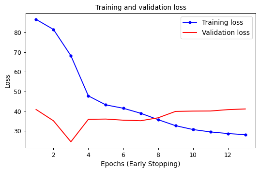

```python
plot_NN(model,history,X_train_DL, y_train_DL)
```

```python
from sklearn import metrics

pred = model.predict(X_valid_DL)
score = np.sqrt(metrics.mean_squared_error(pred,y_valid_DL))
print("Score (RMSE): {}".format(score))
```

```
Score (RMSE): 53.951575201958775
```

### Recurrent Neural Network (RNN)

```python
from tensorflow.keras.preprocessing import sequence
from keras.layers import Dense, SimpleRNN
from tensorflow.keras.layers import LSTM
from tensorflow.keras.datasets import imdb
```

When dealing with time series (and other types of sequences such as sentences), the input features are generally represented as 3D arrays of shape **[batch size (number of time series), time steps, dimensionality]**, where dimensionality is 1 for univariate time series and more for multivariate time series.**

```python
n_output=6
df_train_rnn = df_sunspot_gb[df_sunspot_gb.date<'2000']
df_train_rnn.reset_index(drop=True, inplace=True)
data_train= df_Series_to_Supervised(df_train_rnn[['sn_value']], n_input=n_input,n_output=n_output)
target_clmn=data_train.columns[-n_output:]
X_train_nn = data_train.drop(target_clmn, axis = 1).values
y_train_nn = data_train[target_clmn].values
#scaler = StandardScaler()
#X_train_nn = scaler.fit_transform(X_train_nn)
X_train_nn = X_train_nn.reshape(len(X_train_nn),n_input,1)

#
df_valid_rnn = df_sunspot_gb[(df_sunspot_gb.date>='2000')]
df_valid_rnn.reset_index(drop=True, inplace=True)
data_valid= df_Series_to_Supervised(df_valid_rnn[['sn_value']], n_input=n_input,n_output=n_output)

X_valid_nn = data_valid.drop(target_clmn, axis = 1).values
y_valid_nn = data_valid[target_clmn].values
#scaler = StandardScaler()
#X_valid_nn = scaler.fit_transform(X_valid_nn)
X_valid_nn = X_valid_nn.reshape(len(X_valid_nn),n_input,1)
```

```python
np.random.seed(42)
tf.random.set_seed(42)

model_rnn = keras.models.Sequential()
model_rnn.add(keras.layers.SimpleRNN(50, input_shape=(None,1)))
model_rnn.add(keras.layers.Dense(32))
model_rnn.add(keras.layers.Dense(n_output))
# Compile model
model_rnn.compile(loss="mse", optimizer="adam")

# Early stopping to avoid overfitting
monitor= keras.callbacks.EarlyStopping(monitor='val_loss', min_delta=0,patience=10000, mode='auto')

history = model_rnn.fit(X_train_nn, y_train_nn,
                    validation_data=(X_valid_nn, y_valid_nn),callbacks=[monitor],verbose=1,epochs=10)
```

```
Score (RMSE): 21.942071161841888
```

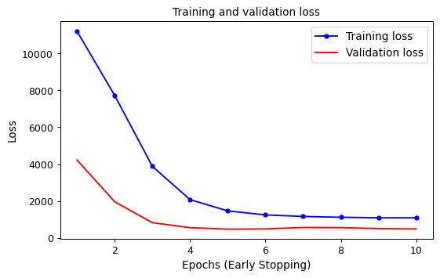

```python
from sklearn import metrics
plot_NN(model,history,X_valid_nn, y_valid_nn)

pred = model_rnn.predict(X_valid_nn)
score = np.sqrt(metrics.mean_squared_error(pred,y_valid_nn))
print("Score (RMSE): {}".format(score))
```

```python
n_input=12  #12 Month input
n_output=6  #6 Month output

# Number of simulation
nsim=10

pred_no_all,full_test_nsim_all_rnn,full_test_nsim_m_rnn,MAE_all_rnn,X_train_ts_rnn, y_train_ts_rnn=time_series_forecst(n_input,n_output
              ,nsim, model_rnn,X_train,clm='sn_value',no='No.', data_out=True,deep_learning='rnn',
              epochs=10,test1=X_test,test2=test_2022,test3=test_2023,test4=test_2024,test5=test_2025)
```

[output not shown]

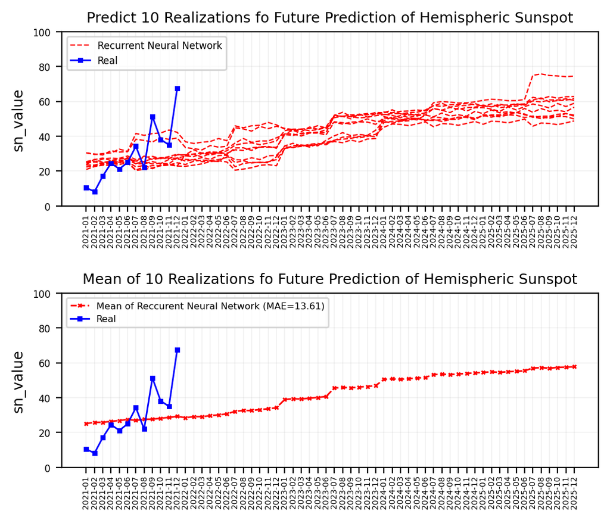

```python
date=X_test['date'].astype(str).values.tolist()+test_2022['date'
            ].astype(str).values.tolist()+test_2023['date'].astype(str).values.tolist()+test_2024['date'
            ].astype(str).values.tolist()+test_2025['date'].astype(str).values.tolist()

date_real=X_test['sn_value'].to_list()+test_2022['sn_value'].to_list()+test_2023['sn_value'
            ].to_list()+test_2024['sn_value'].to_list()+test_2025['sn_value'].to_list()

font = {'size'   :6 }
plt.rc('font', **font)
fig=plt.figure(figsize=(6, 5), dpi= 200, facecolor='w', edgecolor='k')
ax1=plt.subplot(2,1,1)

# Number of prediction
n_pred= 5
# Make realizations
for i in range(nsim):
    real=[]
    for j in range(n_pred):
        real=real+full_test_nsim_all_rnn[j][i]
    if i==0:
        label='Recurrent Neural Network'
    else:
        label= None
    plt.plot(np.ravel(pred_no_all),real,'r--',linewidth=0.8,label=label)

plt.plot(np.ravel(pred_no_all),date_real,'bs-',markersize=2,linewidth=1.0,label='Real')
ax1.grid(axis='both',linewidth='0.1')
plt.title(f"Predict {nsim} Realizations fo Future Prediction of Hemispheric Sunspot",fontsize=9)
plt.ylabel('sn_value',fontsize=9)
plt.xticks(np.ravel(pred_no_all), date,rotation=90,fontsize=5,y=0.02)
plt.legend(loc=2,fontsize=6,markerscale=1.1)
plt.ylim(0,100)

ax1=plt.subplot(2,1,2)

# Mean of realizations
plt.plot(np.ravel(pred_no_all),np.ravel(full_test_nsim_m_rnn),'rx--',markersize=2,
         linewidth=1.0,label=f'Mean of Reccurent Neural Network (MAE={np.round(MAE_all_rnn[0],2)})')

plt.plot(np.ravel(pred_no_all),date_real,
         'bs-',markersize=2,linewidth=1.0,label='Real')

ax1.grid(axis='both',linewidth='0.1')
plt.title(f"Mean of {nsim} Realizations fo Future Prediction of Hemispheric Sunspot",fontsize=9)
plt.ylabel('sn_value',fontsize=9)
plt.xticks(np.ravel(pred_no_all), date,rotation=90,fontsize=5,y=0.02)
plt.legend(loc=2,fontsize=5.8,markerscale=1.1)
plt.ylim(0,100)
plt.subplots_adjust(hspace=0.5)

plt.show()
```

### LSTM (Long Short-Term Memory)

```python
from tensorflow.keras.preprocessing import sequence
from tensorflow.keras.models import Sequential
from tensorflow.keras.layers import Dense, Embedding
from tensorflow.keras.layers import LSTM
from tensorflow.keras.datasets import imdb
from tensorflow.keras.callbacks import EarlyStopping
```

```python
model = Sequential()
model.add(LSTM(50, dropout=0.0, recurrent_dropout=0.0,input_shape=(None, 1)))
model.add(Dense(32))
model.add(Dense(n_output))
model.compile(loss='mean_squared_error', optimizer='adam')
monitor = EarlyStopping(monitor='val_loss', min_delta=1e-3, patience=5,
                        verbose=1, mode='auto', restore_best_weights=True)
history = model.fit(X_train_nn, y_train_nn,
                    validation_data=(X_valid_nn, y_valid_nn),callbacks=[monitor],verbose=1,epochs=10)
```

```python
from sklearn import metrics

pred = model.predict(X_valid_nn)
score = np.sqrt(metrics.mean_squared_error(pred,y_valid_nn))
print("Score (RMSE): {}".format(score))
```

```
Score (RMSE): 20.925946773513488
```

```python
n_input=12  #12 Month input
n_output=6 #6 Month output

# Number of simulation
nsim=10

pred_no_all,full_test_nsim_all_rnn,full_test_nsim_m_rnn,MAE_all_rnn,X_train_ts_rnn, y_train_ts_rnn=time_series_forecst(n_input,n_output
              ,nsim, model_rnn,X_train,clm='sn_value',no='No.', data_out=True,deep_learning='lstm',
              epochs=50,test1=X_test,test2=test_2022,test3=test_2023,test4=test_2024,test5=test_2025)
```

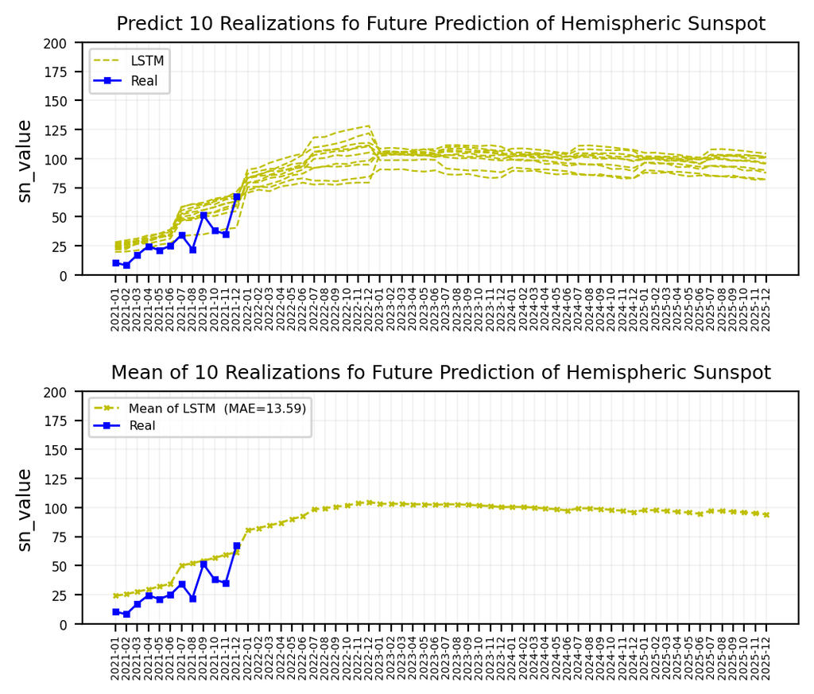

```python
date=X_test['date'].astype(str).values.tolist()+test_2022['date'
            ].astype(str).values.tolist()+test_2023['date'].astype(str).values.tolist()+test_2024['date'
            ].astype(str).values.tolist()+test_2025['date'].astype(str).values.tolist()

date_real=X_test['sn_value'].to_list()+test_2022['sn_value'].to_list()+test_2023['sn_value'
            ].to_list()+test_2024['sn_value'].to_list()+test_2025['sn_value'].to_list()

font = {'size'   :6 }
plt.rc('font', **font)
fig=plt.figure(figsize=(6, 5), dpi= 200, facecolor='w', edgecolor='k')
ax1=plt.subplot(2,1,1)

# Number of prediction
n_pred= 5
# Make realizations
for i in range(nsim):
    real=[]
    for j in range(n_pred):
        real=real+full_test_nsim_all_rnn[j][i]
    if i==0:
        label='LSTM'
    else:
        label= None
    plt.plot(np.ravel(pred_no_all),real,'y--',linewidth=0.8,label=label)

plt.plot(np.ravel(pred_no_all),date_real,'bs-',markersize=2,linewidth=1.0,label='Real')
ax1.grid(axis='both',linewidth='0.1')
plt.title(f"Predict {nsim} Realizations fo Future Prediction of Hemispheric Sunspot",fontsize=9)
plt.ylabel('sn_value',fontsize=9)
plt.xticks(np.ravel(pred_no_all), date,rotation=90,fontsize=5,y=0.02)
plt.legend(loc=2,fontsize=6,markerscale=1.1)
plt.ylim(0,200)

ax1=plt.subplot(2,1,2)

# Mean of realizations
plt.plot(np.ravel(pred_no_all),np.ravel(full_test_nsim_m_rnn),'yx--',markersize=2,
         linewidth=1.0,label=f'Mean of LSTM  (MAE={np.round(MAE_all_rnn[0],2)})')

plt.plot(np.ravel(pred_no_all),date_real,
         'bs-',markersize=2,linewidth=1.0,label='Real')

ax1.grid(axis='both',linewidth='0.1')
plt.title(f"Mean of {nsim} Realizations fo Future Prediction of Hemispheric Sunspot",fontsize=9)
plt.ylabel('sn_value',fontsize=9)
plt.xticks(np.ravel(pred_no_all), date,rotation=90,fontsize=5,y=0.02)
plt.legend(loc=2,fontsize=5.8,markerscale=1.1)
plt.ylim(0,200)
plt.subplots_adjust(hspace=0.5)

plt.show()
```

# Total Energy Consumption in Alberta

The data can be downloaded from this [link](https://www.aeso.ca/market/market-and-system-reporting/) by clicking on *2019 annual market statistics data file*

```python
df = pd.read_csv('2009-2019-Annual-Market-Statistics-data-file.csv')
df.insert(loc=0, column='No.', value=df.index.to_list())
df['date'] =pd.to_datetime(df['Month'])
df.head()
```

|  | No. | Month | Total energy (GWh) | Average hourly load (MW) | Maximum hourly load (MW) | Minimum hourly load (MW) | Year-over-year average load growth (%) | Load factor (%) | date |
| --- | --- | --- | --- | --- | --- | --- | --- | --- | --- |
| 0 | 0 | Jan-2009 | 6281 | 8442 | 9753 | 7221 | -0.01 | 0.87 | 2009-01-01 |
| 1 | 1 | Feb-2009 | 5627 | 8373 | 9465 | 7321 | 0.00 | 0.89 | 2009-02-01 |
| 2 | 2 | Mar-2009 | 6074 | 8175 | 9307 | 6952 | 0.01 | 0.88 | 2009-03-01 |
| 3 | 3 | Apr-2009 | 5491 | 7626 | 8507 | 6690 | -0.02 | 0.90 | 2009-04-01 |
| 4 | 4 | May-2009 | 5519 | 7418 | 8375 | 6454 | -0.01 | 0.89 | 2009-05-01 |

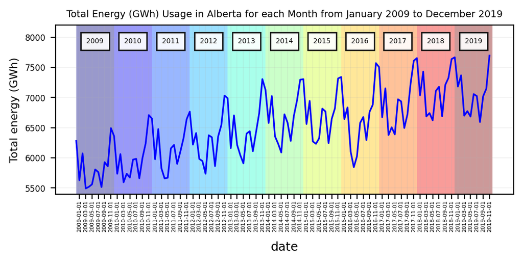

```python
font = {'size'   :6 }
plt.rc('font', **font)
fig=plt.figure(figsize=(6, 5), dpi= 200, facecolor='w', edgecolor='k')
ax1=plt.subplot(2,1,1)

date=df['date'].astype(str).values.tolist()
tot_Engy=df['Total energy (GWh)'].values.tolist()
plt.plot(date,tot_Engy,color='b',linewidth=1.2)
ax1.grid(axis='both',linewidth='0.1')
plt.xticks(np.arange(1,len(date)+1),date)
ax1.set_xticklabels(date, rotation=90,fontsize=4,y=0.02)
plt.title('Total Energy (GWh) Usage in Alberta for each Month from January 2009 to December 2019',fontsize=7)

plt.xlabel('date',fontsize=9,labelpad=7)
plt.ylabel('Total energy (GWh)',fontsize=8)

jet= plt.get_cmap('jet')
colors = plt.cm.jet(np.linspace(0,1,11))

for imnth in range(0,11):
    plt.axvspan(12*imnth,12*(imnth+1), facecolor=colors[imnth], alpha=0.4)
    plt.text(6*(imnth+(imnth+1))-2.8, 7900,str(2009+imnth),fontsize=5,bbox=dict(facecolor='w', alpha=0.9))

plt.ylim((5400,8200))
plt.locator_params(axis='x', nbins=100)
plt.show()
```

## Training and Test sets

```python
# Training set for years less than 2018
X_train = df[df['date']<'2019']
#X_train.reset_index(drop=True, inplace=True)

# Test set for the year 2019
X_test = df[df['date']>='2019']
#X_test.reset_index(drop=True, inplace=True)
```

## Prediction with Supervised Learning

```python
# Train LinearRegression
n_input=12 # 12 Months input
n_output=12 # 12 Months output
nsim=10
model=LinearRegression()
pred_no_all,full_test_nsim_all,full_test_nsim_m,MAE_all=time_series_forecst(n_input,n_output
                    ,nsim, model,X_train,clm='Total energy (GWh)',no='No.',test1=X_test)
```

### Cross-Validation on Time-Series data

### Predictive Algorithms

```
Linear Regression: 0.595596 (0.253720)
Neural Network: 0.640703 (0.200810)
Decision Tree: -0.840864 (0.542906)
Random Forest: 0.128323 (0.235372)
```

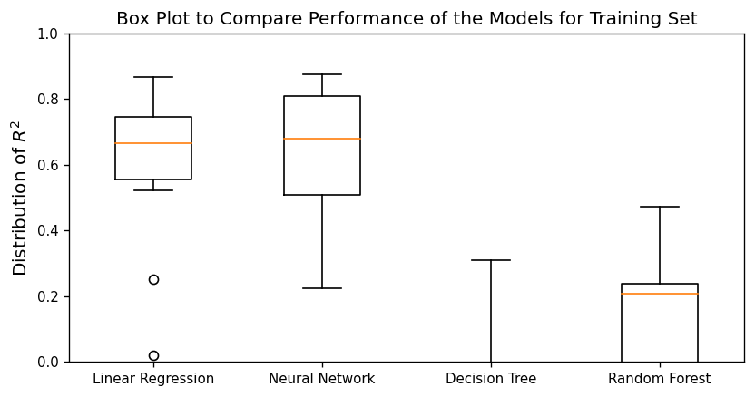

```python
font = {'size'   : 9}
plt.rc('font', **font)
fig, ax1 = plt.subplots(figsize=(8, 4), dpi= 120, facecolor='w', edgecolor='k')

# Spot Check Algorithms
np.random.seed(42)
models = []
models.append(('Linear Regression', LinearRegression()))
models.append(('Neural Network', MLPRegressor(solver = 'lbfgs')))
models.append(('Decision Tree', DecisionTreeRegressor()))
models.append(('Random Forest', RandomForestRegressor(n_estimators = 100)))
# Evaluate each model in turn
results = []
names = []
for name, model in models:
    # TimeSeries Cross validation
    tscv = TimeSeriesSplit(n_splits=10)

    # Train models
    pred_no_all,full_test_nsim_all,full_test_nsim_m,MAE_all,X_train_ts, y_train_ts=time_series_forecst(n_input,n_output
                        ,1, model,X_train,clm='Total energy (GWh)',no='No.', data_out=True,test1=X_test)

    cv_results = cross_val_score(model, X_train_ts, y_train_ts, cv=tscv, scoring='r2')
    results.append(cv_results)
    names.append(name)
    print('%s: %f (%f)' % (name, cv_results.mean(), cv_results.std()))

# Compare Algorithms
plt.ylim((0,1))
plt.boxplot(results,meanline=True, labels=names)
plt.ylabel('Distribution of '+r"$R^{2}$",fontsize=12)
plt.title('Box Plot to Compare Performance of the Models for Training Set',fontsize=12)
plt.show()
```

```python
# Make empty Total energy (GWh) for year 2020
test_2020=[f'2020-{"%02d" % (i+1,)}' for i in range(12)]
test_2020=pd.DataFrame(test_2020,columns=['date'])
test_2020['Total energy (GWh)']=len(test_2020)*[np.nan]
#
# Make empty Total energy (GWh) for year 2021
test_2021=[f'2021-{"%02d" % (i+1,)}' for i in range(12)]
test_2021=pd.DataFrame(test_2021,columns=['date'])
test_2021['Total energy (GWh)']=len(test_2021)*[np.nan]
#
# Make empty Total energy (GWh) for year 2022
test_2022=[f'2022-{"%02d" % (i+1,)}' for i in range(12)]
test_2022=pd.DataFrame(test_2022,columns=['date'])
test_2022['Total energy (GWh)']=len(test_2022)*[np.nan]
#
# Make empty Total energy (GWh) for year 2023
test_2023=[f'2023-{"%02d" % (i+1,)}' for i in range(12)]
test_2023=pd.DataFrame(test_2023,columns=['date'])
test_2023['Total energy (GWh)']=len(test_2023)*[np.nan]
```

```python
n_input=12  #12 Month input
n_output=12 #12 Month output

# Number of simulation
nsim=20
model=RandomForestRegressor(n_estimators = 100)
pred_no_all,full_test_nsim_all_rf,full_test_nsim_m_rf,MAE_all_rf,X_train_ts_rf, y_train_ts_rf=time_series_forecst(n_input,n_output
                    ,nsim, model,X_train,clm='Total energy (GWh)',no='No.', data_out=True,test1=X_test,
                    test2=test_2020,test3=test_2021,test4=test_2022,test5=test_2023)
#
model=LinearRegression()
pred_no_all,full_test_nsim_all_lr,full_test_nsim_m_lr,MAE_all_lr,X_train_ts_lr, y_train_ts_lr=time_series_forecst(n_input,n_output
                    ,nsim, model,X_train,clm='Total energy (GWh)',no='No.', data_out=True,test1=X_test,
                    test2=test_2020,test3=test_2021,test4=test_2022,test5=test_2023)
#
model=MLPRegressor(solver = 'lbfgs')
pred_no_all,full_test_nsim_all_ml,full_test_nsim_m_ml,MAE_all_ml,X_train_ts_ml, y_train_ts_ml=time_series_forecst(n_input,n_output
                    ,nsim, model,X_train,clm='Total energy (GWh)',no='No.', data_out=True,test1=X_test,
                    test2=test_2020,test3=test_2021,test4=test_2022,test5=test_2023)
#
model=DecisionTreeRegressor()
pred_no_all,full_test_nsim_all_dt,full_test_nsim_m_dt,MAE_all_dt,X_train_ts_dt, y_train_ts_dt=time_series_forecst(n_input,n_output
                    ,nsim, model,X_train,clm='Total energy (GWh)',no='No.', data_out=True,test1=X_test,
                    test2=test_2020,test3=test_2021,test4=test_2022,test5=test_2023)
```

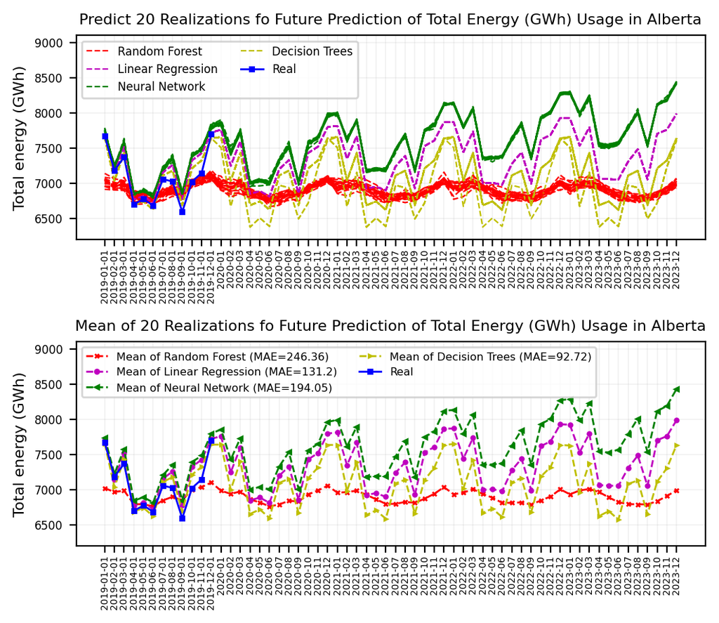

```python
date=X_test['date'].astype(str).values.tolist()+test_2020['date'
            ].astype(str).values.tolist()+test_2021['date'].astype(str).values.tolist()+test_2022['date'
            ].astype(str).values.tolist()+test_2023['date'].astype(str).values.tolist()

date_real=X_test['Total energy (GWh)'].to_list()+test_2020['Total energy (GWh)'].to_list()+test_2021['Total energy (GWh)'
            ].to_list()+test_2022['Total energy (GWh)'].to_list()+test_2023['Total energy (GWh)'].to_list()

font = {'size'   :6 }
plt.rc('font', **font)
fig=plt.figure(figsize=(6, 5), dpi= 200, facecolor='w', edgecolor='k')
ax1=plt.subplot(2,1,1)

# Number of prediction
n_pred= 5
# Make realizations
for i in range(nsim):
    real=[]
    for j in range(n_pred):
        real=real+full_test_nsim_all_rf[j][i]
    if i==0:
        label='Random Forest'
    else:
        label= None
    plt.plot(np.ravel(pred_no_all),real,'r--',linewidth=0.8,label=label)
    #
    real=[]
    for j in range(n_pred):
        real=real+full_test_nsim_all_lr[j][i]
    if i==0:
        label='Linear Regression'
    else:
        label= None
    plt.plot(np.ravel(pred_no_all),real,'m--',linewidth=0.8,label=label)
    #
    real=[]
    for j in range(n_pred):
        real=real+full_test_nsim_all_ml[j][i]
    if i==0:
        label='Neural Network'
    else:
        label= None
    plt.plot(np.ravel(pred_no_all),real,'g--',linewidth=0.8,label=label)
    #
    real=[]
    for j in range(n_pred):
        real=real+full_test_nsim_all_dt[j][i]
    if i==0:
        label='Decision Trees'
    else:
        label= None
    plt.plot(np.ravel(pred_no_all),real,'y--',linewidth=0.8,label=label)

plt.plot(np.ravel(pred_no_all),date_real,'bs-',markersize=2,linewidth=1.0,label='Real')
ax1.grid(axis='both',linewidth='0.1')
plt.title(f"Predict {nsim} Realizations fo Future Prediction of Total Energy (GWh) Usage in Alberta",fontsize=8)
plt.ylabel('Total energy (GWh)',fontsize=8)
plt.xticks(np.ravel(pred_no_all), date,rotation=90,fontsize=5,y=0.02)
plt.legend(loc=2,ncol=2,fontsize=6,markerscale=1.1)
plt.ylim(6200,9100)

ax1=plt.subplot(2,1,2)

# Mean of realizations
plt.plot(np.ravel(pred_no_all),np.ravel(full_test_nsim_m_rf),'rx--',markersize=2,
         linewidth=1.0,label=f'Mean of Random Forest (MAE={np.round(MAE_all_rf[0],2)})')
plt.plot(np.ravel(pred_no_all),np.ravel(full_test_nsim_m_lr),'mo--',markersize=2,
         linewidth=1.0,label=f'Mean of Linear Regression (MAE={np.round(MAE_all_lr[0],2)})')
plt.plot(np.ravel(pred_no_all),np.ravel(full_test_nsim_m_ml),'g<--',markersize=2,
         linewidth=1.0,label=f'Mean of Neural Network (MAE={np.round(MAE_all_ml[0],2)})')
plt.plot(np.ravel(pred_no_all),np.ravel(full_test_nsim_m_dt),'y>--',markersize=1.5,
         linewidth=1.0,label=f'Mean of Decision Trees (MAE={np.round(MAE_all_dt[0],2)})')

plt.plot(np.ravel(pred_no_all),date_real,
         'bs-',markersize=2,linewidth=1.0,label='Real')

ax1.grid(axis='both',linewidth='0.1')
plt.title(f"Mean of {nsim} Realizations fo Future Prediction of Total Energy (GWh) Usage in Alberta",fontsize=8)
plt.ylabel('Total energy (GWh)',fontsize=8)
plt.xticks(np.ravel(pred_no_all), date,rotation=90,fontsize=5,y=0.02)
plt.legend(loc=2,ncol=2,fontsize=5.8,markerscale=1.1)
plt.ylim(6200,9100)
plt.subplots_adjust(hspace=0.5)

plt.show()
```

**Deep Learning cannot be applied for this data set because of limited sampled data.**

# Appendix

```python
def df_Series_to_Supervised(df, n_input=1, n_output=1, remove_nan=True):
    """
    Convert DataFrame time series to a supervised learning dataset.

    df: DataFrame time series
    n_input: Input observations as training features (X)
    n_output: Output observations target (y)
    remove_nan: drop missing values (NaN)

    """
    Vars=df.columns
    Clms, Nms = [],[]
    # input sequence (t-n, ... t-1)
    for i in range(n_input, 0, -1):
        Clms.append(df.shift(i))
        Nms+=[('Var%d(t-%d)' % (j+1, i)) for j in range(len(Vars))]
    # predict sequence (t, t+1, ... t+n)
    for i in range(0, n_output):
        Clms.append(df.shift(-i))
        if i == 0:
            Nms+= [('Var%d(t)' % (j+1)) for j in range(len(Vars))]
        else:
            Nms+=[('Var%d(t+%d)' % (j+1, i)) for j in range(len(Vars))]
    # concat all
    df_f = concat(Clms, axis=1)
    df_f.columns = Nms
    # drop rows with NaN values if needed
    if remove_nan:
        df_f.dropna(inplace=True)
    return df_f

##################################################

def time_series_forecst(n_input,n_output,nsim, model,X_train,clm='value',
                        no='date',data_out=False,deep_learning=False,epochs=10,**kwargs):

    """
    Predict time series by suppervised learning

    n_input : number of input features (should be number of samples in one complete series)
    n_output: number of output targets
    nsim:   : number of simulations (realizations)
    model   : predictive algorithms
    X_train : training time series as Pandas DataFrame
    clm     : column name for the feature in X_train DataFrame
    no      : date for the feature in X_train DataFrame
    data_out: True, it returns xtrain and ytrain
    **kwargs: individual test sets (for example, test1=October, test2=November, test3=December...)
    """

    def dl_rnn(n_out,seed=42):
        """
        Recurrent Neural Network
        """
        np.random.seed(seed)
        tf.random.set_seed(seed)
        model_rnn = keras.models.Sequential()
        model_rnn.add(keras.layers.SimpleRNN(50, input_shape=(None,1)))
        model_rnn.add(keras.layers.Dense(32))
        model_rnn.add(keras.layers.Dense(n_out))
        # Compile model
        model_rnn.compile(loss="mse", optimizer="adam")
        return model_rnn
    #
    def dl_lstm(n_out,seed=42):
        """
        LSTM (Long Short-Term Memory)
        """
        np.random.seed(seed)
        tf.random.set_seed(seed)
        model_lstm = keras.models.Sequential()
        model_lstm.add(keras.layers.LSTM(50, input_shape=(None,1)))
        model_lstm.add(keras.layers.Dense(32))
        model_lstm.add(keras.layers.Dense(n_out))
        # Compile model
        model_lstm.compile(loss="mse", optimizer="adam")
        return model_lstm

    # Convert time series to suppervised learning:
    train_ts= df_Series_to_Supervised(X_train[[clm]], n_input=n_input,
                                  n_output=n_output, remove_nan=True)
    target_clmn=train_ts.columns[-n_output:]
    x_train_ts = train_ts.drop(target_clmn, axis = 1)
    y_train_ts = train_ts[target_clmn]

    input_sample_df=X_train[clm]

    if (n_input%n_output!=0):
        raise ValueError('Remainder of n_input/n_output is not zero, please increase or decrease n_output')

    if (len(kwargs.items())>1 and nsim==1):
        raise ValueError('nsim should be >1 for perdiction next series')

    n_loops=int(n_input/n_output)

    pred_no_all=[]
    full_test_nsim_all=[]
    full_test_nsim_m=[]
    MAE_all=[]
    ir=0
    if deep_learning=='rnn':
        model=dl_rnn(seed=42,n_out=n_output)
        history=model.fit(x_train_ts.values, y_train_ts.values,epochs=epochs,verbose=0)
    elif deep_learning=='lstm':
        model=dl_lstm(seed=42,n_out=n_output)
        history=model.fit(x_train_ts.values, y_train_ts.values,epochs=epochs,verbose=0)
    else:
        model=model.fit(x_train_ts.values, y_train_ts.values)
    for key, test in kwargs.items():
        # First series to predict
        if (ir==0):
            tmp_no=[]
            full_test_nsim=[]
            MAE=0
            for isim in range(nsim):
                full_test=[]
                for ilp in range(n_loops):
                    if ((n_input-ilp*n_output)>0):
                        X_new=input_sample_df.iloc[-(n_input-ilp*n_output):].to_list()+full_test
                        if deep_learning=='rnn':
                            model=dl_rnn(seed=43+isim,n_out=n_output)
                            model.fit(x_train_ts.values, y_train_ts.values,epochs=epochs,verbose=0)
                        elif deep_learning=='lstm':
                            model=dl_lstm(seed=43+isim,n_out=n_output)
                            model.fit(x_train_ts.values, y_train_ts.values,epochs=epochs,verbose=0)
                        else:
                            model=model.fit(x_train_ts.values, y_train_ts.values)
                        pred=model.predict(np.array(np.array(X_new).reshape(1,n_input)))
                        if (isim==0):
                            tmp=list(test[no][ilp*n_output:(ilp+1)*n_output])
                            tmp_no.append(tmp)
                        if ((n_input-ilp*n_output)<n_output):
                            full_test=full_test+list(pred[0][:(n_input-ilp*n_output)])
                        else:
                            full_test=full_test+list(pred[0])
                full_test_nsim.append(full_test)
                MAE=MAE/nsim+np.nanmean([abs(full_test[i]-test[clm].iloc[i]) for i in range(len(full_test))])

            if (nsim>1):
                full_test_m=[sum(full_test_nsim[j][i]/nsim for j in range(nsim)) for i in range(len(full_test_nsim[0]))]

            pred_no_all.append(list(itertools.chain(*tmp_no)))
            full_test_nsim_all.append(full_test_nsim)
            if (nsim> 1): full_test_nsim_m.append(full_test_m)
            MAE_all.append(MAE)

        else:
            new_series=[full_test_nsim_m[ir-1][i] if math.isnan(test[clm].iloc[i]) else test[clm].iloc[i]
                       for i in range(len(full_test_nsim_m[ir-1]))]
            tmp_no=[]
            MAE=0
            full_test_nsim=[]
            for isim in range(nsim):
                full_test=[]
                for ilp in range(n_loops):
                    if ((n_input-ilp*n_output)>0):
                        X_new=new_series[-(n_input-ilp*n_output):]+full_test
                        if deep_learning=='rnn':
                            model=dl_rnn(seed=43+isim,n_out=n_output)
                            model.fit(x_train_ts.values, y_train_ts.values,epochs=epochs,verbose=0)
                        elif deep_learning=='lstm':
                            model=dl_lstm(seed=43+isim,n_out=n_output)
                            model.fit(x_train_ts.values, y_train_ts.values,epochs=epochs,verbose=0)
                        else:
                            model=model.fit(x_train_ts.values, y_train_ts.values)
                        pred=model.predict(np.array(np.array(X_new).reshape(1,n_input)))

                        if ((n_input-ilp*n_output)<n_output):
                            full_test=full_test+list(pred[0][:(n_input-ilp*n_output)])
                        else:
                            full_test=full_test+list(pred[0])
                full_test_nsim.append(full_test)
                MAE=MAE/nsim+np.nanmean([abs(full_test[i]-test[clm].iloc[i]) for i in range(len(full_test))])
            if (nsim>1):
                full_test_m=[sum(full_test_nsim[j][i]/nsim for j in range(nsim)) for i in range(len(full_test_nsim[0]))]
            pred_no_tmp=[max(pred_no_all[ir-1])+i+1 for i in range(n_input)]
            pred_no_all.append(pred_no_tmp)
            full_test_nsim_all.append(full_test_nsim)
            if (nsim> 1): full_test_nsim_m.append(full_test_m)
            MAE_all.append(MAE)

        ir+=1
    if data_out:
        return pred_no_all,full_test_nsim_all,full_test_nsim_m,MAE_all,x_train_ts,y_train_ts

    else:
        return pred_no_all,full_test_nsim_all,full_test_nsim_m,MAE_all

##################################################

def plot_NN(model,history,x_train,y_train):
    """ Plot training loss versus validation loss and
    training accuracy versus validation accuracy"""

    font = {'size'   : 10}
    plt.rc('font', **font)
    fig, ax=plt.subplots(figsize=(15, 9), dpi= 90, facecolor='w', edgecolor='k')

    ax1 = plt.subplot(2,2,1)
    history_dict = history.history
    loss_values = history_dict['loss']
    val_loss_values = history_dict['val_loss']
    epochs = range(1, len(loss_values) + 1)
    ax1.plot(epochs, loss_values, 'b-o',markersize=4, label='Training loss')
    ax1.plot(epochs, val_loss_values, 'r-', label='Validation loss')
    plt.title('Training and validation loss',fontsize=11)
    plt.xlabel('Epochs (Early Stopping)',fontsize=11)
    plt.ylabel('Loss',fontsize=11)
    plt.legend(fontsize='11')
```